# Reproducible Research: Peer Assessment 1

## Loading and preprocessing the data

Assuming the activity.zip file is in the working directory, we will first unzip source file and read it

```r
unzip("activity.zip")
data <- read.csv("activity.csv")
```

## What is mean total number of steps taken per day?

For this part of the assignment, you can ignore the missing values in the data set.

Calculate the total number of steps taken per day

If you do not understand the difference between a histogram and a bar plot, research the difference between them. Make a histogram of the total number of steps taken each day

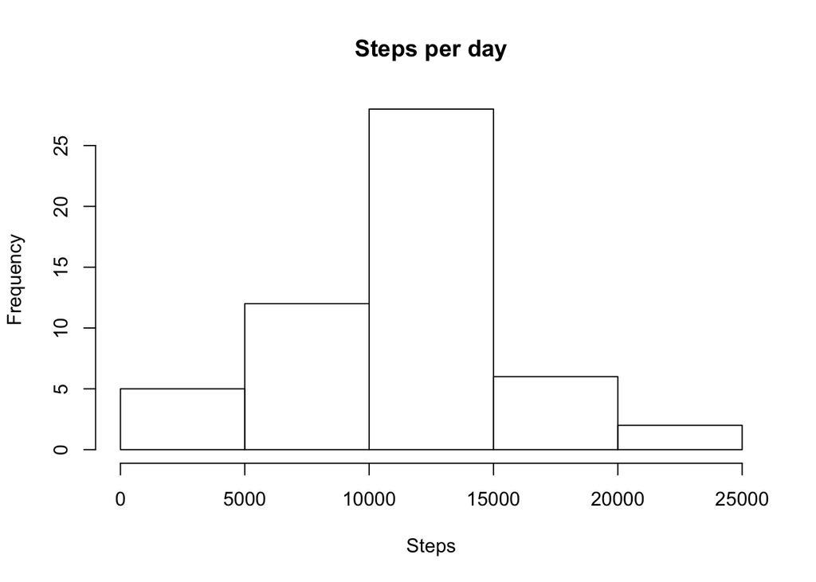

```r
daily_steps <- aggregate(steps ~ date, data = data,FUN = sum)

steps_mean <- mean(daily_steps$steps)

steps_median <- median(daily_steps$steps)

hist(daily_steps$steps, xlab = "Steps", main = "Steps per day")
```

## What is the average daily activity pattern?

Make a time series plot (i.e. type = “l”) of the 5-minute interval (x-axis) and the average number of steps taken, averaged across all days (y-axis)

Which 5-minute interval, on average across all the days in the data set, contains the maximum number of steps?

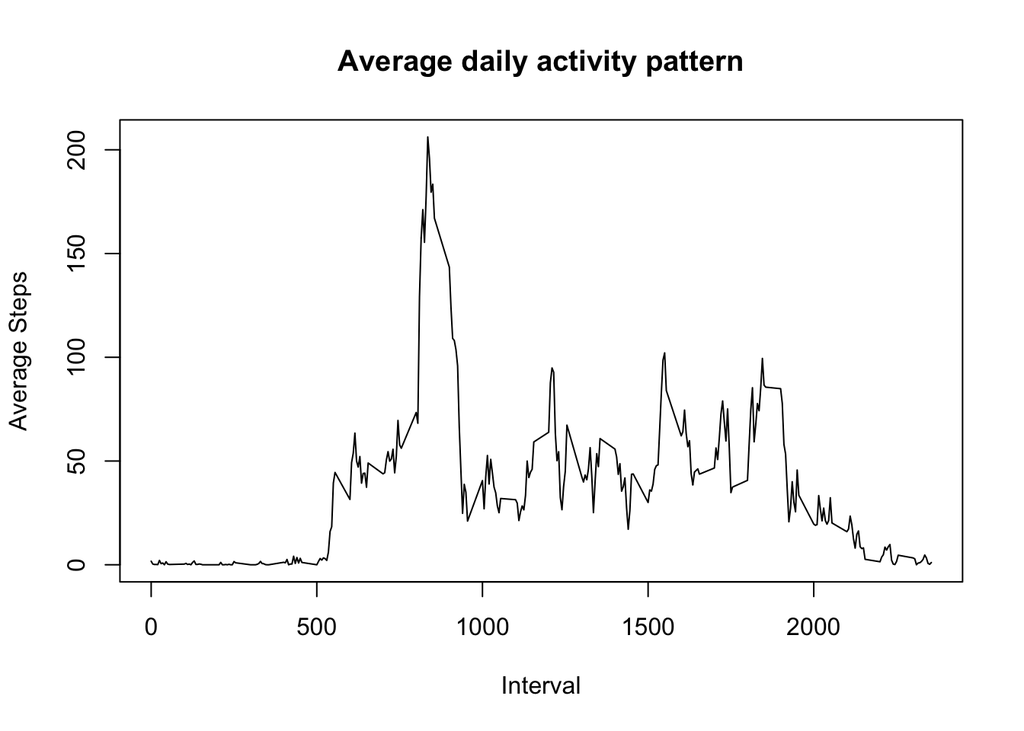

```r
interval_average <- aggregate(steps ~ interval, data = data, FUN = mean)

max_interval <- interval_average[interval_average$steps == max(interval_average$steps),1]

plot(interval_average$interval,interval_average$steps,type = "l",xlab = "Interval",ylab="Average Steps", main = "Average daily activity pattern")
```

The interval with maximum steps is 835

## Imputing missing values

Note that there are a number of days/intervals where there are missing values (coded as NA). The presence of missing days may introduce bias into some calculations or summaries of the data.

Devise a strategy for filling in all of the missing values in the data set. The strategy does not need to be sophisticated. For example, you could use the mean/median for that day, or the mean for that 5-minute interval, etc.

Create a new data set that is equal to the original data set but with the missing data filled in.

[figure not shown]

```r
total_nas <- sum(is.na(data$steps))

treated_data <- data

for (counter in 1:length(treated_data$date)){
        if (is.na(treated_data$steps[[counter]])){
                treated_data$steps[counter] = mean(data$steps[data$interval == treated_data$interval[counter]],na.rm = T)
        }
}


treated_daily_steps <- aggregate(steps ~ date, data = treated_data,FUN = sum)

treated_steps_mean <- mean(treated_daily_steps$steps)

treated_steps_median <- median(treated_daily_steps$steps)

par(mfrow=c(2,1))

hist(daily_steps$steps, xlab = "Steps", main = "Steps per day")

hist(treated_daily_steps$steps, xlab = "Steps", main = "Steps per day with missing values")
```

we can see that there was a small amount of variation.

## Are there differences in activity patterns between weekdays and weekends?

Create a new factor variable in the data set with two levels – “weekday” and “weekend” indicating whether a given date is a weekday or weekend day.

Make a panel plot containing a time series plot (i.e. type = “l”) of the 5-minute interval (x-axis) and the average number of steps taken, averaged across all weekday days or weekend days (y-axis). See the README file in the Git Hub repository to see an example of what this plot should look like using simulated data.

```r
data$WeekDay <- factor(weekdays(as.POSIXct(data$date)) %in%  c("Saturday","Sunday"),labels=c("Week day", "Weekend"))

weekday_interval_average <- aggregate(steps ~ interval + WeekDay, data = data, FUN = mean)

require(lattice)
```

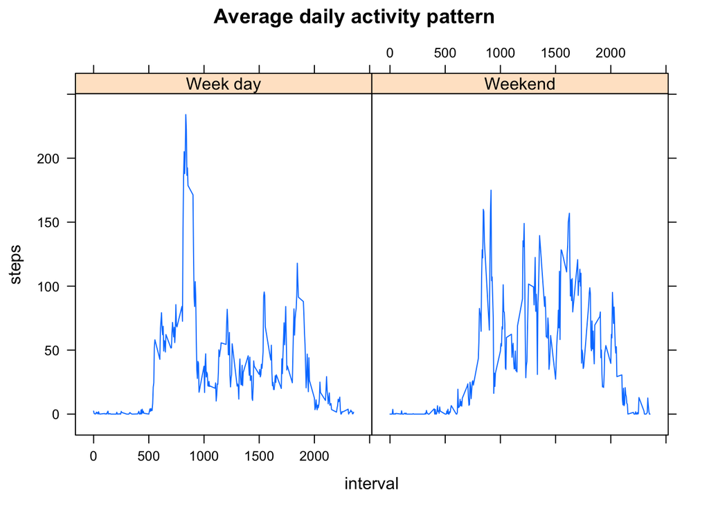

```r
xyplot(steps ~ interval | WeekDay,data = weekday_interval_average,type="l", main = "Average daily activity pattern")
```